# Getting Over It

Visualising my Transalp bike ride

Julian During  
2021-05-23

This summer I crossed the alps with my road bike. I’ve recorded the whole ride and as a nice memory, I would like to visualise this ride.

A short time ago I’ve discovered the awesome R package `drake`. The use of this package transformed the way I do my analysis and it helps me to make my post more reproducible. The following [blog post](https://milesmcbain.xyz/the-drake-post/) describes the underlying workflow, after which I’ve developed the underlying package `transalp` for this post.

# Data

At first you have to install the package from github. Then you have to load it.

```r
remotes::install_github("duju211/transalp")

library(transalp)
```

Load the other necessary libraries:

```r
library(tidyverse)
library(patchwork)
library(drake)
library(here)
library(fs)
```

The package includes the underlying data:

```r
df_act_meas_raw <- transalp::df_act_meas
```

```
# A tibble: 90,917 x 10
   id         act_date   moving velocity_smooth grade_smooth distance
   <chr>      <date>     <lgl>            <dbl>        <dbl>    <dbl>
 1 3669729902 2020-06-25 FALSE              0            0        0
 2 3669729902 2020-06-25 FALSE              0            0        0.9
 3 3669729902 2020-06-25 TRUE               0          -44.6      4.6
 4 3669729902 2020-06-25 TRUE               0            1.4      8.4
 5 3669729902 2020-06-25 TRUE               0            2.8     12.1
 6 3669729902 2020-06-25 TRUE               0            2.8     15.6
 7 3669729902 2020-06-25 TRUE               0            1.4     19.1
 8 3669729902 2020-06-25 TRUE               3.6          1.4     22.5
 9 3669729902 2020-06-25 TRUE               3.5          0       26
10 3669729902 2020-06-25 TRUE               3.5          1.6     29.5
# ... with 90,907 more rows, and 4 more variables: altitude <dbl>,
#   time <int>, lat <dbl>, lng <dbl>
```

# Preprocessing

Look at the first function:

```r
#' Function to preprocess measurements of the included activities.
#'
#' @param df_act_meas
#'
#' @return Preprocessed activities
#' @export
#'
#' @examples
#' pre_process_meas(df_act_meas)
pre_process_meas <- function(df_act_meas) {
  df_act_meas %>%
    dplyr::mutate(
      act_date_chr = as.character(act_date),
      altitude_norm = altitude / max(altitude)) %>%
    dplyr::group_by(id) %>%
    dplyr::mutate(distance_norm = distance / max(distance)) %>%
    dplyr::ungroup()
}
```

The function does some basic preprocessing on the included activities:

- Turn activity date into character (for easier plotting)
- Normalize altitude and distance

```r
df_act_meas <- pre_process_meas(df_act_meas_raw)
```

Nest the data frame by `id` and `act_date_chr`. Create a new `sf` column with the geospatial information of the activities:

```r
#' Turn every activity into an sf object. Nest the data frame by 'id' and
#' 'act_date_chr' to do this.
#'
#' @param df_act_meas
#'
#' @return sf object
#' @export
#'
#' @examples
convert_to_sf <- function(df_act_meas) {
  df_act_meas %>%
    tidyr::nest(act_data = -c(id, act_date_chr)) %>%
    dplyr::mutate(
      line = purrr::map(
        act_data,
        ~ sf::st_linestring(as.matrix(.x[, c("lng", "lat", "altitude")]))),
      geom = purrr::map(line, sf::st_sfc, crs = 4326)) %>%
    sf::st_as_sf()
}
```

```r
sf_act_meas <- convert_to_sf(df_act_meas)
```

```
Simple feature collection with 5 features and 4 fields
Geometry type: LINESTRING
Dimension:     XYZ
Bounding box:  xmin: 8.317612 ymin: 46.0061 xmax: 9.035269 ymax: 48.21307
z_range:       zmin: 206.8 zmax: 2477.6
CRS:           NA
# A tibble: 5 x 5
  id     act_date_chr act_data                             line geom
  <chr>  <chr>        <list>                       <LINESTRING> <list>
1 36697~ 2020-06-25   <tibble [~ Z (8.596761 46.63501 1451.6, ~ <LINE~
2 36646~ 2020-06-24   <tibble [~ Z (8.602206 46.63612 1510.2, ~ <LINE~
3 36590~ 2020-06-23   <tibble [~ Z (8.625703 46.90152 447, 8.6~ <LINE~
4 36542~ 2020-06-22   <tibble [~ Z (8.741265 47.49397 432, 8.7~ <LINE~
5 36504~ 2020-06-21   <tibble [~ Z (9.021049 48.21307 750.2, 9~ <LINE~
```

Extract the start point of every tour except for the last one. Extract the end point for this tour.

```r
#' Extract points of interest.
#'
#' @param sf_act_meas
#'
#' @return Data frame with points of interest
#' @export
#'
#' @examples
extract_poi <- function(sf_act_meas) {
  sf_act_meas %>%
    tibble::as_tibble() %>%
    dplyr::transmute(
      id, first_row = purrr::map(act_data, ~ .x[1,]),
      last_row = purrr::map(act_data, ~ .x[nrow(.x), ]),
      decisive_row = dplyr::if_else(id == "3669729902", last_row, first_row)) %>%
    tidyr::unnest(decisive_row) %>%
    dplyr::select(where(purrr::negate(purrr::is_list))) %>%
    dplyr::mutate(
      poi_name = dplyr::case_when(
        act_date == "2020-06-21" ~ "Albstadt",
        act_date == "2020-06-22" ~ "Winterthur",
        act_date == "2020-06-23" ~ "Flüelen",
        act_date == "2020-06-24" ~ "Andermatt",
        act_date == "2020-06-25" ~ "Lugano",
        TRUE ~ NA_character_)) %>%
    dplyr::rename(lon = lng)
}
```

```r
df_poi <- extract_poi(sf_act_meas)
```

# Visualisation

## Altitude

Visualise the altitude data:

```r
#' Visualise the altitude by using a ridge plot.
#'
#' @param df_act_meas
#'
#' @return ggplot of altitude data
#' @export
#'
#' @examples
vis_altitude_ridge <- function(df_act_meas) {
  df_act_meas %>%
    tibble::as_tibble() %>%
    tidyr::unnest_legacy(act_data) %>%
    dplyr::mutate(distance = distance / 1000) %>%
    ggplot2::ggplot(ggplot2::aes(
      x = distance, y = act_date_chr, height = altitude,
      group = act_date_chr, color = act_date_chr)) +
    ggridges::geom_ridgeline(scale = 0.0025, alpha = 0.2) +
    ggplot2::labs(
      x = "Distance [km]", y = ggplot2::element_blank()) +
    ggplot2::theme_light() +
    ggplot2::theme(
      legend.position = "none") +
    ggplot2::scale_y_discrete(position = "right") +
    ggplot2::scale_x_continuous(breaks = scales::breaks_width(10))
}
```

The function mainly applies the `ggridges::geom_ridgeline` function to the data. A form of visualisation that I’ve already used a lot. Its style is reminiscent of the famous Joy Division album cover.

```r
gg_altitude_ridges <- vis_altitude_ridge(sf_act_meas)
```

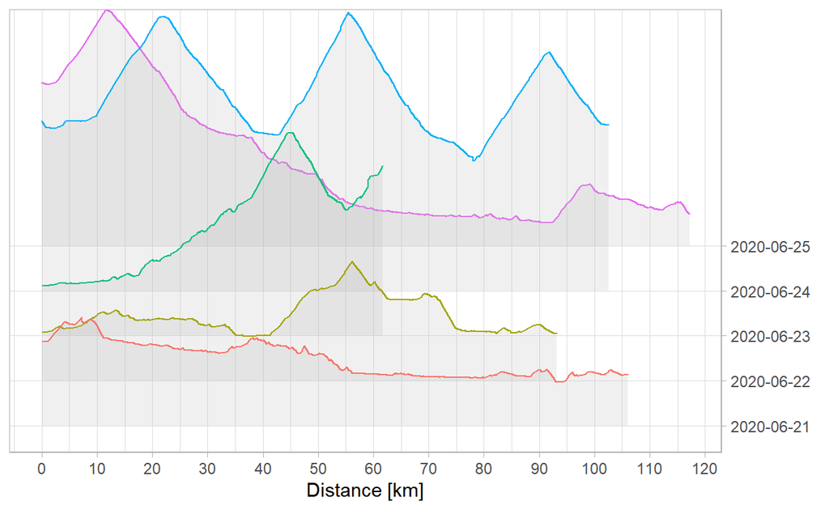

## Spatial Data

Determine the map data for all the activities. Use the `ggmap::get_stamenmap` function to download the data. The bounding box is calculated from the `sf_act_meas` object.

```r
#' Get the ground map for the visualisation of the spatial data.
#'
#' @param sf_act_meas
#' @param tol_bbox
#' @param map_zoom
#'
#' @return
#' @export
#'
#' @examples
get_alpen_map <- function(sf_act_meas, tol_bbox = 0.015, map_zoom = 10) {
  bbox <- sf::st_bbox(sf_act_meas)

  stamen_map <- ggmap::get_stamenmap(
    bbox = c(
      left = bbox$xmin[[1]] - tol_bbox,
      right = bbox$xmax[[1]] + tol_bbox,
      bottom = bbox$ymin[[1]] - tol_bbox,
      top = bbox$ymax[[1]] + tol_bbox),
    maptype = "terrain-background", zoom = map_zoom, color = "bw")
}
```

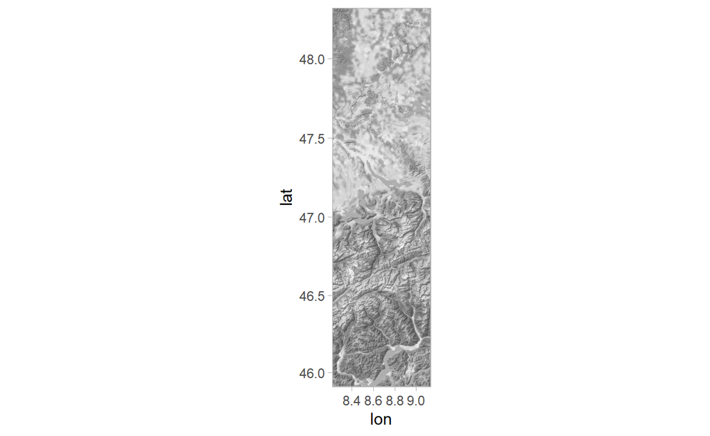

```r
gg_alpen <- get_alpen_map(sf_act_meas, tol_bbox = 0.1, map_zoom = 9)
```

Plot the activity and the point of interest data onto the map. Use the `ggrepel` package to plot the labels of the points of interest. This avoids too much overplotting.

```r
#' Plot the spatial data (route + point of interest) onto the map
#'
#' @param sf_act_meas
#' @param gg_alpen
#'
#' @return ggplot of spatial data
#' @export
#'
#' @examples
vis_ride <- function(sf_act_meas, gg_alpen, df_poi) {
  ggmap::ggmap(gg_alpen) +
    ggplot2::geom_sf(
      data = sf_act_meas, inherit.aes = FALSE,
      mapping = aes(color = act_date_chr), size = 1.2) +
    ggrepel::geom_label_repel(
      data = df_poi, mapping = aes(label = poi_name), alpha = 0.6,
      family = "Fira Code Retina", size = 2.5) +
    ggplot2::theme_light() +
    ggplot2::labs(
      x = "Longitude", y = "Latitude") +
    ggplot2::theme(legend.position = "none")
}
```

```r
gg_rides <- vis_ride(sf_act_meas, gg_alpen_map, df_poi)
```

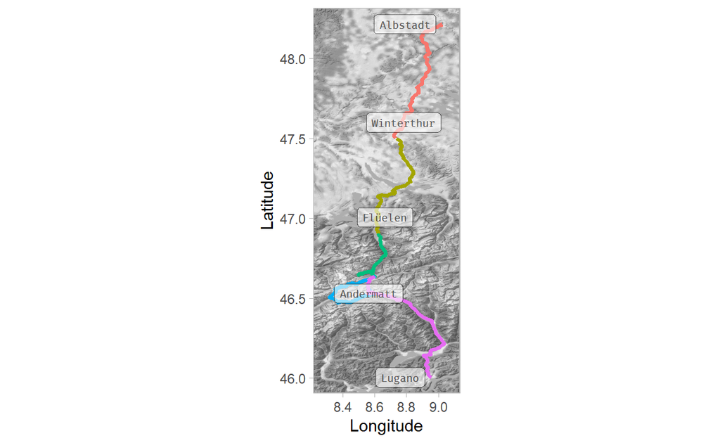

## Combine Visualisations

Combine everything into one big plot using the `patchwork` package:

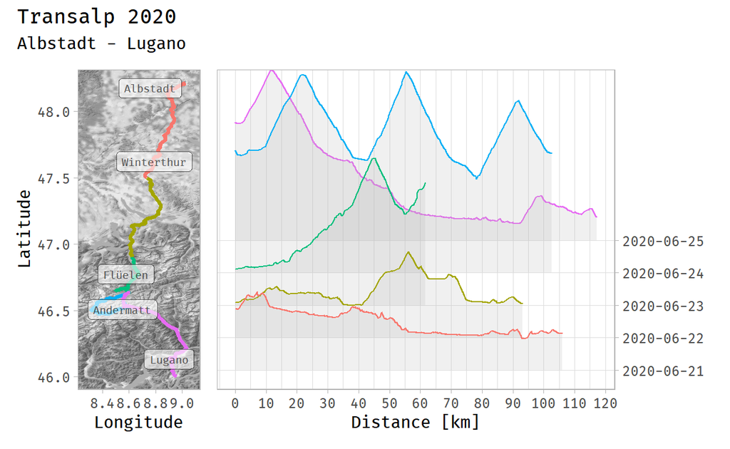

```r
# extrafont::font_import()
extrafont::loadfonts(device = "win")

final_plot <- (gg_rides + gg_altitude_ridges) +
      plot_annotation(
        title = "Transalp 2020",
        subtitle = "Albstadt - Lugano") &
      theme(text = element_text(family = "Fira Code Retina"))

final_plot
```

The `extrafont` package helps with using some fancy fonts. The `font_import` function has to be called once. Comment the function call in the above code chunk because of this.